# Investigation of Loan Data from Prosper

## by Adolf Nefischer

## Investigation Overview

> What factors affect a loan’s outcome status?

## Dataset Overview

> This project investigates the Loan Data from Prosper and shows the relationship within the data. This data set contains 113,937 loans with 81 variables on each loan, including loan amount, borrower rate (or interest rate), current loan status, borrower income, and many others.

## Loan Status

> Bevore we start any work the actual Loan Status is investigated and cleaned up, i.e. verious categories of "Past due xx days" and even Chargedoff loans are merged together. As we are interessted in the outcome we only look at Completed and failed loans.

```
Loan Status:
Completed: 66.74%
Failed: 33.26%
```

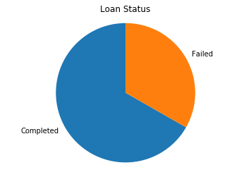

```python
loanstatus = dfs['LoanStatus'].value_counts()
label = 'Completed', 'Failed'
plt.pie(loanstatus, labels=label, startangle=90)
plt.axis('equal')
plt.title('Loan Status');

print('Loan Status:')
print('Completed:',"{:.2%}".format(loanstatus[0]/sum(loanstatus)))
print('Failed:',"{:.2%}".format(loanstatus[1]/sum(loanstatus)))
```

## Loan Status and Debt To Income Ratio

> We now have a close look of how the cleaned up loan status correlates to the Debt To Income Ratio. Failed loans seem to have a higher Dept To Income Ratio.

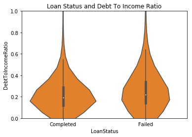

```python
ax = sb.violinplot(data = dfs, x = 'LoanStatus', y = 'DebtToIncomeRatio',
                    color = sb.color_palette()[1]);
ax.set_ylim(0, 1);
plt.title('Loan Status and Debt To Income Ratio');
```

## Loan Status across Income Range and Debt To Income Ratio

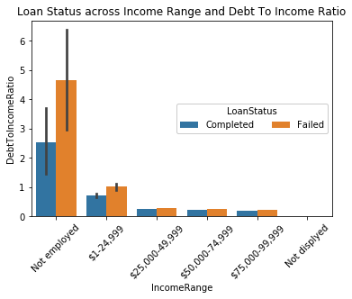

```python
income_order = ["Not employed", "$1-24,999", "$25,000-49,999", "$50,000-74,999", "$75,000-99,999", "Not displyed"]
ax = sb.barplot(data = dfs, x = 'IncomeRange', y = 'DebtToIncomeRatio', hue = 'LoanStatus', order = income_order)
ax.legend(loc = 7, ncol = 3, framealpha = 1, title = 'LoanStatus')
plt.title('Loan Status across Income Range and Debt To Income Ratio');
plt.xticks(rotation = 45);
```